### Explore Attributes and Class

Group 4: Identify an explain interesting relationships between features and dependent variable popularity which is a Yes or No

```python
import matplotlib.pyplot as plt
import pandas as pd
import seaborn as sb
import numpy as np
```

```python
dataset2 = pd.read_csv('C:/DataScience/Stats3/OnlineNewPopularityTransformed.csv')
```

Lets look at popularity by data channel

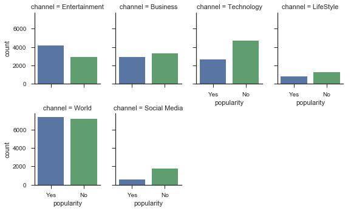

```python
sb.factorplot("popularity", col="channel", col_wrap=4,data=dataset,kind="count", size=2.5, aspect=.8)
plt.show()
```

Does number of videos in as content matter? Below side-by-side plot shows that there is no strong evidence of it. But, we can see exponential raise in videos is not particularly favorable. Social media, however shows a very positive correlation with number of videos.

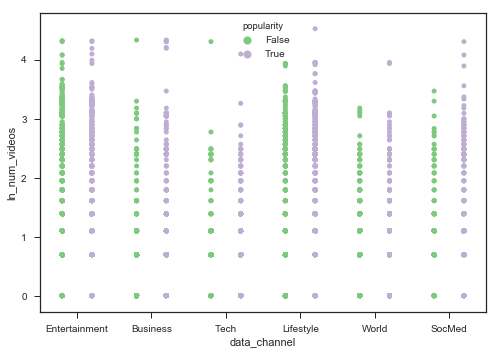

```python
sb.stripplot(x='data_channel',y='ln_num_videos',data=dataset2,hue='popularity', split=True,palette="Accent");
plt.show()
```

### online behaviour on mashable by day of week:

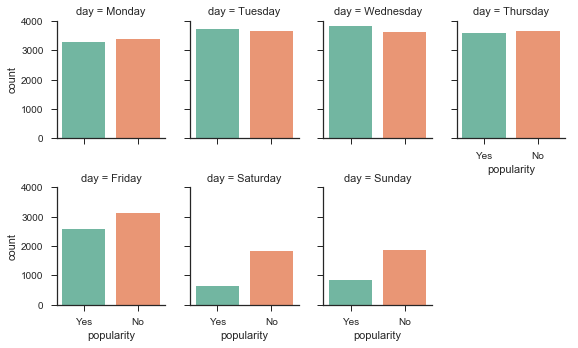

```python
sb.factorplot("popularity", col="day", col_wrap=4,data=dataset,kind="count", size=2.5, aspect=.8,palette="Set2")
plt.show()
```

The plots above indicates that the activity on mashable is low over weekends.Articles published during weekends are less likely to be shared than published mid-week.

Does having images have an impact on popularity? Lets plot it out!

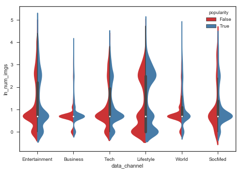

```python
sb.violinplot(x='data_channel',y='ln_num_imgs',data=dataset2,hue='popularity', split=True,palette="Set1");
plt.show()
```

Violin plots above by data channel shows there is some impact on images on popularity. Social media contents with images around exponential 1 to 2 is evenly positioned for popularity. whereas, business popularity increase with images.

content with images is highly populary in lifestyle channel compared to other channels.

Lets look at images impact by day of week.

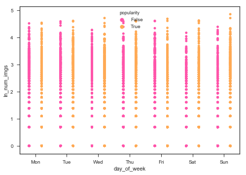

```python
sb.stripplot(x='day_of_week',y='ln_num_imgs',data=dataset2,hue='popularity', split=True,palette="spring");
plt.show()
```

### Moving on to Key words, How important is it to have buzz words to influence people to share?

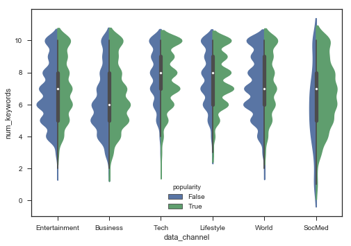

```python
sb.violinplot(x='data_channel',y='num_keywords',data=dataset2, hue='popularity', split=True,scale='count');
plt.show()
```

Next, how long is the title?

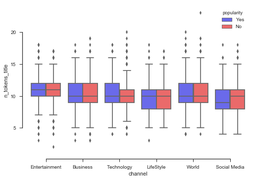

```python
sb.set(style="ticks")
sb.boxplot(x='channel',y='n_tokens_title',data=dataset,hue = 'popularity', palette="seismic" )
sb.despine(offset=10, trim=True)
plt.show()
```

### New Features

Two new features have been added to data analysis.

1. data_Channel:  
   • Business  
   • Entertainment  
   • LifeStyle  
   • Social Media  
   • Technology  
   • World

above variables are derived using the corresponding data_channel indicators.

1. day_of_week:  
   • Mon  
   • Tue  
   • Wed  
   • Thu  
   • Fri  
   • Sat  
   • Sun

above variables are derived using weekday_is_monday thru weekday_is_sunday in the original dataset.